# HDS5301: Regression Methods – HW 6 Answer Key

Published

March 6, 2026

1. **Transformations to Linear Models.** For each of the following nonlinear models, find a transformation of the response variable $Y$ and/or the predictor variable $X$ that linearizes the relationship. Specify the transformed variables $Y^*$ and $X^*$ and express the linear model in the form $Y^* = \beta_0^* + \beta_1^* X^*$. (Note: Ignore the error term for this exercise and focus on the deterministic part of the model).
   1. $Y = \alpha e^{\beta X}$ (Exponential Growth/Decay)
   2. $Y = \alpha X^{\beta}$ (Power Law)
   3. $Y = \frac{1}{\alpha + \beta X}$ (Reciprocal)
   4. $Y = \frac{X}{\alpha + \beta X}$ (Michaelis-Menten type)
   5. $Y = \frac{e^{\alpha+\beta X}}{1+e^{\alpha+\beta X}}$ (Logistic Function)
   6. $Y = \alpha e^{-\beta / X}$ (Arrhenius Equation)

   **Answer:**
   1. **Exponential Growth/Decay:** $Y = \alpha e^{\beta X}$
      Take the natural logarithm of both sides:
      $$\ln(Y) = \ln(\alpha) + \beta X$$
      Let $Y^* = \ln(Y)$, $X^* = X$, $\beta_0^* = \ln(\alpha)$, and $\beta_1^* = \beta$.
   2. **Power Law:** $Y = \alpha X^{\beta}$
      Take the natural logarithm of both sides:
      $$\ln(Y) = \ln(\alpha) + \beta \ln(X)$$
      Let $Y^* = \ln(Y)$, $X^* = \ln(X)$, $\beta_0^* = \ln(\alpha)$, and $\beta_1^* = \beta$.
   3. **Reciprocal:** $Y = \frac{1}{\alpha + \beta X}$
      Invert both sides:
      $$\frac{1}{Y} = \alpha + \beta X$$
      Let $Y^* = 1/Y$, $X^* = X$, $\beta_0^* = \alpha$, and $\beta_1^* = \beta$.
   4. **Michaelis-Menten type:** $Y = \frac{X}{\alpha + \beta X}$
      Invert both sides:
      $$\frac{1}{Y} = \frac{\alpha + \beta X}{X} = \frac{\alpha}{X} + \beta$$
      Let $Y^* = 1/Y$, $X^* = 1/X$, $\beta_0^* = \beta$, and $\beta_1^* = \alpha$.
   5. **Logistic Function:** $Y = \frac{e^{\alpha+\beta X}}{1+e^{\alpha+\beta X}}$
      This implies $Y(1+e^{\alpha+\beta X}) = e^{\alpha+\beta X} \Rightarrow Y = e^{\alpha+\beta X}(1-Y) \Rightarrow \frac{Y}{1-Y} = e^{\alpha+\beta X}$.
      Take the natural logarithm:
      $$\ln\left(\frac{Y}{1-Y}\right) = \alpha + \beta X$$
      Let $Y^* = \ln(Y/(1-Y))$ (the logit transformation), $X^* = X$, $\beta_0^* = \alpha$, and $\beta_1^* = \beta$.
   6. **Arrhenius Equation:** $Y = \alpha e^{-\beta / X}$
      Take the natural logarithm:
      $$\ln(Y) = \ln(\alpha) - \beta \left(\frac{1}{X}\right)$$
      Let $Y^* = \ln(Y)$, $X^* = 1/X$, $\beta_0^* = \ln(\alpha)$, and $\beta_1^* = -\beta$.
2. **Diagnostics and Influential Points.** Load the `state.x77` dataset available in base R. Convert it to a data frame: `states <- data.frame(state.x77)`. Fit a multiple linear regression model predicting `Life.Exp` using `Murder`, `HS.Grad`, and `Frost` as predictors.
   1. Fit the model and produce the four standard diagnostic plots (`plot(model)`). Briefly comment on the “Residuals vs Fitted” and “Scale-Location” plots regarding the assumptions of linearity and constant variance.
   2. Calculate the leverage values ($h_{ii}$) for each state. Identify any states with high leverage using the threshold $2p/n$, where $p$ is the number of coefficients (including intercept).
   3. Manually obtain the internally studentized residual: first obtain $\hat{sigma}^2$, and compute $r_i$ by
      $$r_i = \frac{e_i}{\hat{\sigma}\sqrt{1-h_{ii}}}.$$
      Check whether your manually computed studentized residuals match those from `rstandard(model)`. Identify any states with large studentized residuals (e.g., $|r_i| > 2$).
   4. Mannually obtain the externally studentized residual for the 1st observation (Alabama) by first fitting a new model excluding Alabama, obtaining $\hat{\sigma}_{(1)}^2$, and computing $r_1$ by
      $$r_1^{\star} = \frac{e_1}{\hat{\sigma}_{(1)}\sqrt{1-h_{11}}}.$$
      Check whether your manually computed externally studentized residual for Alabama matches that from `rstudent(model)[1]`. Write the loop to compute the externally studentized residuals for all observations. Check whether your manually computed externally studentized residuals match those from `rstudent(model)`. What is the distribution of $r_i^{\star}$ under the null hypothesis of no outliers? Obtain the p-value of $r_i^{\star}$ for all observations. Test the significance of the observations being outliers using the Bonferroni correction.
   5. Calculate Cook’s Distance ($D_i$) for each observation. Using the F-distribution median method from class, identify any influential states.

   **Answer:**

   First, fit the model:

   ```r
   states <- data.frame(state.x77)
   model_states <- lm(Life.Exp ~ Murder + HS.Grad + Frost, data = states)
   summary(model_states)
   ```

   ```
   Call:
   lm(formula = Life.Exp ~ Murder + HS.Grad + Frost, data = states)

   Residuals:
       Min      1Q  Median      3Q     Max
   -1.5015 -0.5391  0.1014  0.5921  1.2268

   Coefficients:
                Estimate Std. Error t value Pr(>|t|)
   (Intercept) 71.036379   0.983262  72.246  < 2e-16 ***
   Murder      -0.283065   0.036731  -7.706 8.04e-10 ***
   HS.Grad      0.049949   0.015201   3.286  0.00195 **
   Frost       -0.006912   0.002447  -2.824  0.00699 **
   ---
   Signif. codes:  0 '***' 0.001 '**' 0.01 '*' 0.05 '.' 0.1 ' ' 1

   Residual standard error: 0.7427 on 46 degrees of freedom
   Multiple R-squared:  0.7127,    Adjusted R-squared:  0.6939
   F-statistic: 38.03 on 3 and 46 DF,  p-value: 1.634e-12
   ```

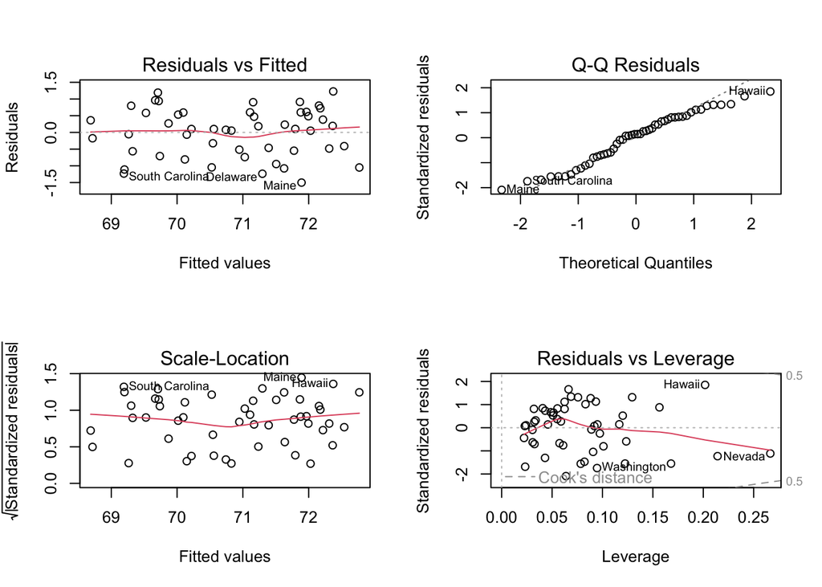

      ```r
      par(mfrow = c(2, 2))
      plot(model_states)
      ```

      ```r
      n <- nrow(states)
      p <- length(coef(model_states)) # 4 coefficients (Intercept + 3 predictors)
      threshold_leverage <- 2 * p / n

      hat_vals <- hatvalues(model_states)
      high_leverage <- names(hat_vals[hat_vals > threshold_leverage])

      print(paste("Threshold:", round(threshold_leverage, 3)))
      ```

      ```
      [1] "Threshold: 0.16"
      ```

      ```r
      print(high_leverage)
      ```

      ```
      [1] "Alaska"     "Hawaii"     "Nevada"     "Washington"
      ```

      The high leverage states (using the $2p/n$ rule for this model) are Alaska, Hawaii, Nevada, and Washington.
   3. **Internally Studentized Residuals:** The formula for internally studentized residuals is:
      $$r_i = \frac{e_i}{\hat{\sigma}\sqrt{1-h_{ii}}}$$

      ```r
      e <- residuals(model_states)
      sigma_hat <- summary(model_states)$sigma
      h <- hatvalues(model_states)

      r_internal_manual <- e / (sigma_hat * sqrt(1 - h))

      # Check against rstandard (which calculates INTERNALLY studentized residuals)
      # list the first few to check manual ones and rstandard
      head(cbind(Manual = r_internal_manual, R_Standard = rstandard(model_states)))
      ```

      ```
                     Manual R_Standard
      Alabama     0.5214480  0.5214480
      Alaska     -1.2284338 -1.2284338
      Arizona    -1.5477595 -1.5477595
      Arkansas    1.3149656  1.3149656
      California  0.8806045  0.8806045
      Colorado    1.2749230  1.2749230
      ```

      ```r
      all.equal(r_internal_manual, rstandard(model_states))
      ```

      ```
      [1] TRUE
      ```

      *Answer:* The manually computed internally studentized residuals match `rstandard(model_states)`.

      Identifying outliers with $|r_i| > 2$:

      ```r
      outliers_internal <- names(r_internal_manual[abs(r_internal_manual) > 2])
      print(outliers_internal)
      ```

      ```
      [1] "Maine"
      ```

      For this model, Maine is flagged by the $|r_i| > 2$ rule.
   4. **Externally Studentized Residuals:** The formula for externally studentized residuals is using $\hat{\sigma}_{(i)}$:
      $$r_i^{\star} = \frac{e_i}{\hat{\sigma}_{(i)}\sqrt{1-h_{ii}}}$$

      First for Alabama (observation 1):

      ```r
      # Fit model without Alabama
      model_no_AL <- lm(Life.Exp ~ Murder + HS.Grad + Frost, data = states[-1, ])
      sigma_i <- summary(model_no_AL)$sigma

      # Manual calculation for Alabama
      r_ext_AL <- e[1] / (sigma_i * sqrt(1 - h[1]))

      print(paste("Manual External (Alabama):", r_ext_AL))
      ```

      ```
      [1] "Manual External (Alabama): 0.517280057384094"
      ```

      ```r
      print(paste("rstudent (Alabama):", rstudent(model_states)[1]))
      ```

      ```
      [1] "rstudent (Alabama): 0.517280057384095"
      ```

      They match.

      Now loop for all observations:

      ```r
      n <- nrow(states)
      r_ext_manual <- numeric(n)

      for(i in 1:n){
        model_i <- lm(Life.Exp ~ Murder + HS.Grad + Frost, data = states[-i, ])
        sigma_i <- summary(model_i)$sigma
        r_ext_manual[i] <- e[i] / (sigma_i * sqrt(1 - h[i]))
      }
      names(r_ext_manual) <- rownames(states)

      # Check match with rstudent
      head(cbind(Manual = r_ext_manual, R_Student = rstudent(model_states)))
      ```

      ```
                     Manual  R_Student
      Alabama     0.5172801  0.5172801
      Alaska     -1.2354415 -1.2354415
      Arizona    -1.5723325 -1.5723325
      Arkansas    1.3257501  1.3257501
      California  0.8784157  0.8784157
      Colorado    1.2838761  1.2838761
      ```

      ```r
      all.equal(r_ext_manual, rstudent(model_states))
      ```

      ```
      [1] TRUE
      ```

      *Answer:* The manually calculated externally studentized residuals match those from `rstudent(model_states)`.

      *Distribution:* Under the null hypothesis of no outliers, the externally studentized residuals $r_i^{\star}$ follow a **t-distribution with $n - p - 1$ degrees of freedom**. Here $n=50, p=4$, so $df = 50 - 4 - 1 = 45$.

      *P-values:* We want to test $H_0: \text{Obs } i \text{ is not an outlier}$. The two-sided p-value is $2 \times (1 - P(T \le |r_i^{\star}|))$.

      ```r
      p_values <- 2 * (1 - pt(abs(r_ext_manual), df = n - p - 1))

      # Show top 5 smallest p-values
      head(sort(p_values))
      ```

      ```
               Maine         Hawaii South Carolina       Delaware          Texas
          0.03513639     0.06375642     0.08120986     0.09222159     0.09726461
         Mississippi
          0.12049290
      ```

      ```r
      # Check if any use Bonferroni correction (0.05/50 = 0.001)
      any(p_values < 0.05/n)
      ```

      ```
      [1] FALSE
      ```

      Maine has the smallest p-value. No observations are significant after Bonferroni correction at $\alpha=0.05$.
   5. **Cook’s Distance:**

      ```r
      cooks_d <- cooks.distance(model_states)
      # Using F-distribution quantile (50th percentile)
      threshold_cooks <- qf(0.5, p, n - p)

      influential <- names(cooks_d[cooks_d > threshold_cooks])
      print(paste("Threshold (F-dist):", round(threshold_cooks, 3)))
      ```

      ```
      [1] "Threshold (F-dist): 0.852"
      ```

      ```r
      print(influential)
      ```

      ```
      character(0)
      ```

      No points are influential based on the F-distribution median threshold.